# NYPD Shooting Incident Report

Anon.

2024-05-06

### Load Packages

First, we will load some packages to help us get started.

```r
library(tidyverse)
```

### Import Data

```r
url_in <- "https://data.cityofnewyork.us/api/views/833y-fsy8/rows.csv?accessType=DOWNLOAD"
shooting_data <- read_csv(url_in)
```

Let’s have a look at a summary of our data.

```r
summary(shooting_data)
```

```
##   INCIDENT_KEY        OCCUR_DATE         OCCUR_TIME           BORO
##  Min.   :  9953245   Length:28562       Length:28562      Length:28562
##  1st Qu.: 65439914   Class :character   Class1:hms        Class :character
##  Median : 92711254   Mode  :character   Class2:difftime   Mode  :character
##  Mean   :127405824                      Mode  :numeric
##  3rd Qu.:203131993
##  Max.   :279758069
##
##  LOC_OF_OCCUR_DESC     PRECINCT     JURISDICTION_CODE LOC_CLASSFCTN_DESC
##  Length:28562       Min.   :  1.0   Min.   :0.0000    Length:28562
##  Class :character   1st Qu.: 44.0   1st Qu.:0.0000    Class :character
##  Mode  :character   Median : 67.0   Median :0.0000    Mode  :character
##                     Mean   : 65.5   Mean   :0.3219
##                     3rd Qu.: 81.0   3rd Qu.:0.0000
##                     Max.   :123.0   Max.   :2.0000
##                                     NA's   :2
##  LOCATION_DESC      STATISTICAL_MURDER_FLAG PERP_AGE_GROUP
##  Length:28562       Mode :logical           Length:28562
##  Class :character   FALSE:23036             Class :character
##  Mode  :character   TRUE :5526              Mode  :character
##
##
##
##
##    PERP_SEX          PERP_RACE         VIC_AGE_GROUP        VIC_SEX
##  Length:28562       Length:28562       Length:28562       Length:28562
##  Class :character   Class :character   Class :character   Class :character
##  Mode  :character   Mode  :character   Mode  :character   Mode  :character
##
##
##
##
##    VIC_RACE           X_COORD_CD        Y_COORD_CD        Latitude
##  Length:28562       Min.   : 914928   Min.   :125757   Min.   :40.51
##  Class :character   1st Qu.:1000068   1st Qu.:182912   1st Qu.:40.67
##  Mode  :character   Median :1007772   Median :194901   Median :40.70
##                     Mean   :1009424   Mean   :208380   Mean   :40.74
##                     3rd Qu.:1016807   3rd Qu.:239814   3rd Qu.:40.82
##                     Max.   :1066815   Max.   :271128   Max.   :40.91
##                                                        NA's   :59
##    Longitude        Lon_Lat
##  Min.   :-74.25   Length:28562
##  1st Qu.:-73.94   Class :character
##  Median :-73.92   Mode  :character
##  Mean   :-73.91
##  3rd Qu.:-73.88
##  Max.   :-73.70
##  NA's   :59
```

### Clean Data

Now, let’s clean our data.

#### Exclude Irrelevant Variables

First, we will get rid of any variables that we do not need for our analysis.

```r
shooting_data <- shooting_data %>%
  select(-c(INCIDENT_KEY,LOC_OF_OCCUR_DESC, JURISDICTION_CODE, LOC_CLASSFCTN_DESC, X_COORD_CD,Y_COORD_CD,Latitude, Longitude, Lon_Lat))
```

#### Missing Data

There is a lot of missing data in this data set. Let’s replace all missing or invalid values with “UNKNOWN”.

```r
shooting_data[shooting_data == "(null)"] <- "UNKNOWN"
shooting_data[is.na(shooting_data)] <- "UNKNOWN"
shooting_data[shooting_data == "U"] <- "UNKNOWN"
```

There are still some values that appear to be incorrect.

- “PERP_AGE_GROUP” contains the values “224”, “940”, and “1020”.
- “VIC_AGE_GROUP” contains the value “1022”.

Let’s change these values to “UNKNOWN” as well.

```r
shooting_data$PERP_AGE_GROUP[shooting_data$PERP_AGE_GROUP == 224] <- "UNKNOWN"
shooting_data$PERP_AGE_GROUP[shooting_data$PERP_AGE_GROUP == 940] <- "UNKNOWN"
shooting_data$PERP_AGE_GROUP[shooting_data$PERP_AGE_GROUP == 1020] <- "UNKNOWN"
shooting_data$VIC_AGE_GROUP[shooting_data$VIC_AGE_GROUP == 1022] <- "UNKNOWN"
```

#### Variable Types

Next, we will change some of the variable types to make them easier to work with.

```r
shooting_data <- shooting_data %>%
  mutate(OCCUR_DATE = mdy(OCCUR_DATE)) %>%
  mutate(BORO = factor(BORO)) %>%
  mutate(PERP_SEX = factor(PERP_SEX)) %>%
  mutate(PERP_RACE = factor(PERP_RACE)) %>%
  mutate(VIC_SEX = factor(VIC_SEX)) %>%
  mutate(VIC_RACE = factor(VIC_RACE)) %>%
  mutate(PERP_AGE_GROUP = factor(PERP_AGE_GROUP,
                                levels = c("UNKNOWN","<18","18-24","25-44","45-64","65+"))) %>%
  mutate(VIC_AGE_GROUP = factor(VIC_AGE_GROUP,
                                levels = c("UNKNOWN","<18","18-24","25-44","45-64","65+")))
```

#### Cleaned Data

Let’s look at a new summary of our data.

```r
summary(shooting_data)
```

```
##    OCCUR_DATE          OCCUR_TIME                  BORO          PRECINCT
##  Min.   :2006-01-01   Length:28562      BRONX        : 8376   Min.   :  1.0
##  1st Qu.:2009-09-04   Class1:hms        BROOKLYN     :11346   1st Qu.: 44.0
##  Median :2013-09-20   Class2:difftime   MANHATTAN    : 3762   Median : 67.0
##  Mean   :2014-06-07   Mode  :numeric    QUEENS       : 4271   Mean   : 65.5
##  3rd Qu.:2019-09-29                     STATEN ISLAND:  807   3rd Qu.: 81.0
##  Max.   :2023-12-29                                           Max.   :123.0
##
##  LOCATION_DESC      STATISTICAL_MURDER_FLAG PERP_AGE_GROUP     PERP_SEX
##  Length:28562       Mode :logical           UNKNOWN:13636   F      :  444
##  Class :character   FALSE:23036             <18    : 1682   M      :16168
##  Mode  :character   TRUE :5526              18-24  : 6438   UNKNOWN:11950
##                                             25-44  : 6041
##                                             45-64  :  699
##                                             65+    :   65
##                                             NA's   :    1
##                           PERP_RACE     VIC_AGE_GROUP      VIC_SEX
##  AMERICAN INDIAN/ALASKAN NATIVE:    2   UNKNOWN:   65   F      : 2760
##  ASIAN / PACIFIC ISLANDER      :  169   <18    : 2954   M      :25790
##  BLACK                         :11903   18-24  :10384   UNKNOWN:   12
##  BLACK HISPANIC                : 1392   25-44  :12973
##  UNKNOWN                       :12288   45-64  : 1981
##  WHITE                         :  298   65+    :  205
##  WHITE HISPANIC                : 2510
##                            VIC_RACE
##  AMERICAN INDIAN/ALASKAN NATIVE:   11
##  ASIAN / PACIFIC ISLANDER      :  440
##  BLACK                         :20235
##  BLACK HISPANIC                : 2795
##  UNKNOWN                       :   70
##  WHITE                         :  728
##  WHITE HISPANIC                : 4283
```

Much better, right? Now, let’s get to work.

### Visualize & Analyze Data

Let’s begin by building some basic visualizations of our data. This will help us to get a sense of any patterns that might exist within the data.

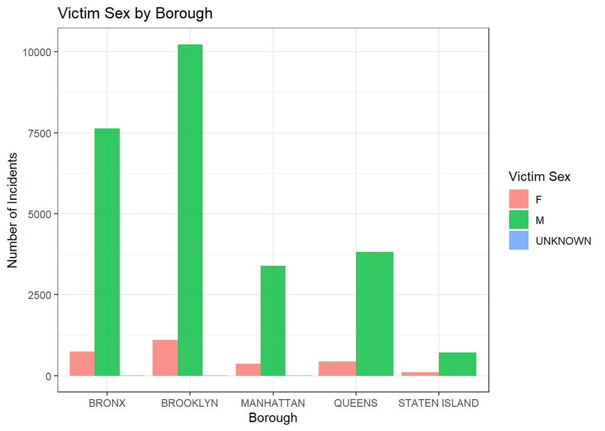

```r
shooting_data %>%
  ggplot(aes(x = BORO, fill = VIC_SEX)) +
  geom_bar(position = "dodge",
           alpha = 0.8) +
  theme_bw() +
  labs(title = "Victim Sex by Borough",
       x = "Borough",
       y = "Number of Incidents",
       fill = "Victim Sex")
```

In this visualization, we can see that the most common victim sex in each borough is **male**—and it isn’t close.

It is also possible to see that **Brooklyn** has had the most total shooting incidents, while **Staten Island** has had the least.

Let’s see if there is a certain time of day in which most incidents occurred.

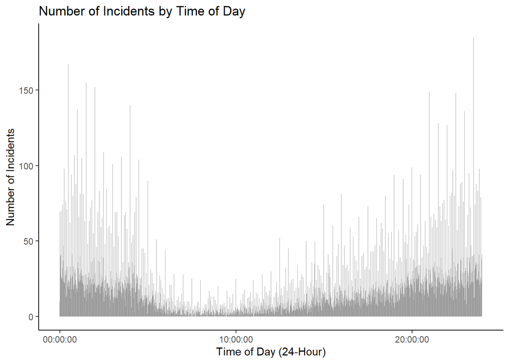

```r
shooting_data %>%
  ggplot(aes(x = OCCUR_TIME)) +
  geom_bar(alpha = 0.5) +
  theme_classic() +
  labs(title = "Number of Incidents by Time of Day",
       x = "Time of Day (24-Hour)",
       y = "Number of Incidents")
```

Here, we can see that most incidents occurred **between evening and early morning**, when it was (presumably) dark outside. There is a clear dip during the daytime—especially in the morning from around 8 - 11 A.M.

Let’s also look at the distribution of incidents according to the date on which they occurred.

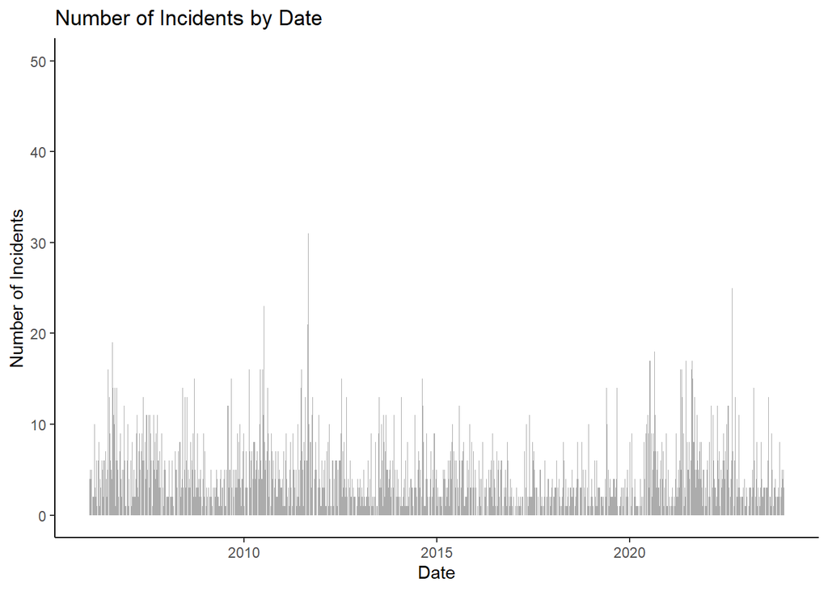

```r
shooting_data %>%
  ggplot(aes(x = OCCUR_DATE)) +
  geom_bar(alpha = 0.5) +
  theme_classic() +
  labs(title = "Number of Incidents by Date",
       x = "Date",
       y = "Number of Incidents") +
  ylim(0,50)
```

There are so many dates present in the visualization that it is difficult to see any pattern that might be present. Thus, we will zoom our visualization in on one year so we can view the data more carefully.

Let’s see which date had the most incidents.

```r
Mode = function(x){
    ta = table(x)
    tam = max(ta)
    if (all(ta == tam))
         mod = NA
    else
         if(is.numeric(x))
    mod = as.numeric(names(ta)[ta == tam])
    else
         mod = names(ta)[ta == tam]
    return(mod)
}
Mode(shooting_data$OCCUR_DATE)
```

```
## [1] "2020-07-05"
```

**July 5, 2020** was the date with the most incidents. 2020 seems to have been an interesting year (perhaps we could have predicted that). Let’s zoom in and see if any pattern emerges.

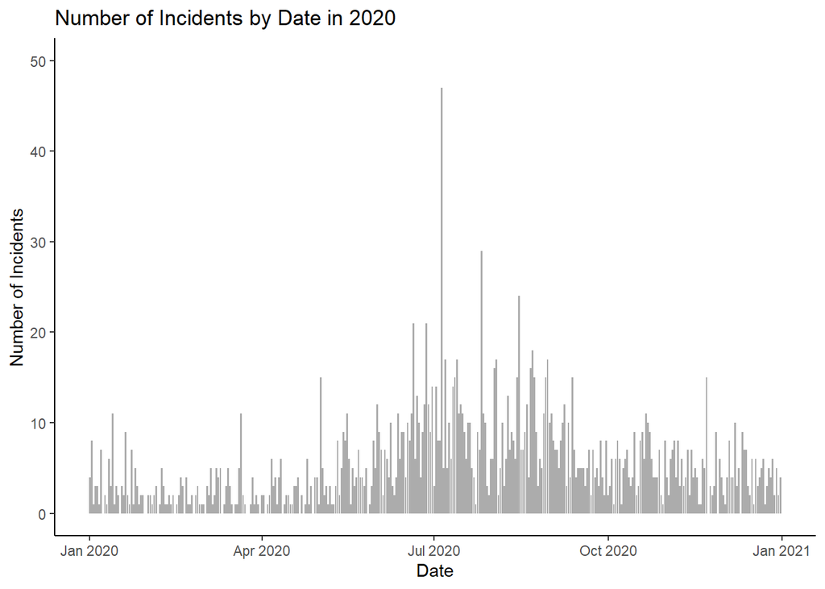

```r
shooting_data %>%
  filter(OCCUR_DATE > "2019-12-31", OCCUR_DATE < "2021-1-1") %>%
  ggplot(aes(x = OCCUR_DATE)) +
  geom_bar(alpha = 0.5) +
  theme_classic() +
  labs(title = "Number of Incidents by Date in 2020",
       x = "Date",
       y = "Number of Incidents") +
  ylim(0,50)
```

According to this graph, incidents seemed to occur more often during the summer months than others.

Let’s pick another year to zoom in on to see if the same pattern emerges.

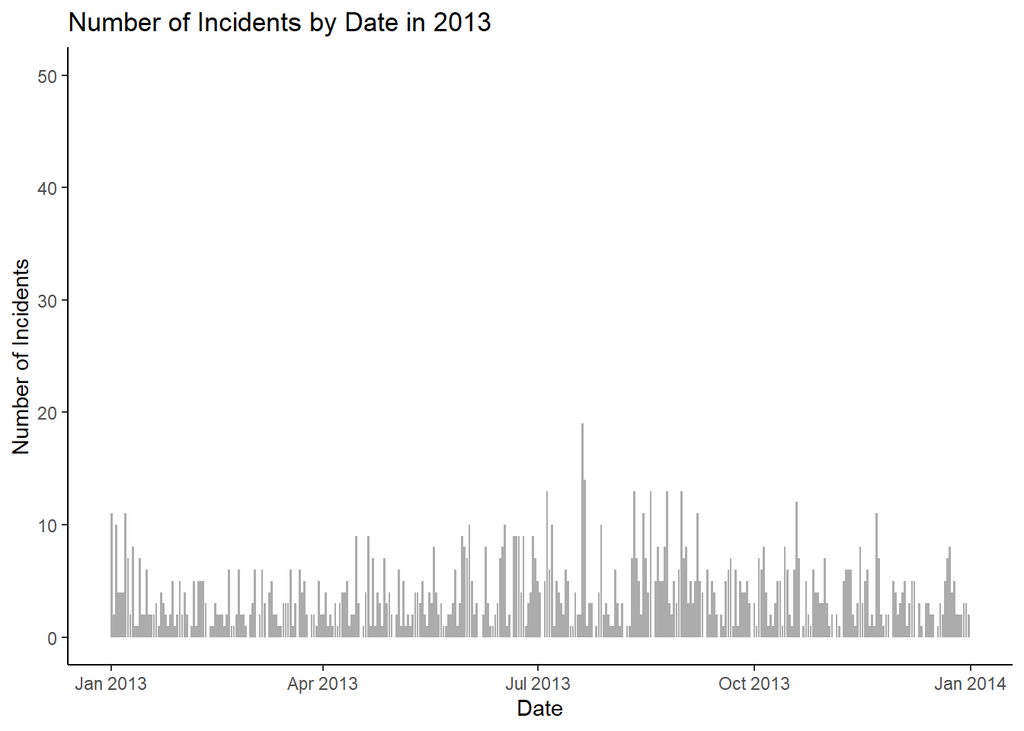

```r
shooting_data %>%
  filter(OCCUR_DATE > "2012-12-31", OCCUR_DATE < "2014-1-1") %>%
  ggplot(aes(x = OCCUR_DATE)) +
  geom_bar(alpha = 0.5) +
  theme_classic() +
  labs(title = "Number of Incidents by Date in 2013",
       x = "Date",
       y = "Number of Incidents") +
  ylim(0,50)
```

While there was not as defined a peak during the summer months of 2013, there still seems to have been some increase during that time of year.